# Beauty reccomendation system - LASSO Model

**Setting up the environment:**

```r
library(quanteda)
library(ggrepel)
library(textclean)
library(tidyverse)
library(glmnet)
library(sentimentr)
library(spacyr)
library(politeness)
```

```r
library(ggplot2)
library(stringr)
library(tm)
library(knitr)
library(stm)
library(jsonlite)
library(svglite)
library(caret)
source("TAB_dfm.R")
source("kendall_acc.R")
data_dfm_train_amazon<-readRDS("function_data_dfm_train_amazon.rds")
data_dfm_test_amazon<-readRDS("function_data_dfm_test_amazon.rds")
data_model_amazon<-readRDS("function_data_model_amazon.rds")
```

**Lasso model using Amazon reviews after lemmatization:**

```r
# Load Amazon reviews file
data_amazon<-read_csv("reviews_df.csv")
# Clean up lemmatized_review and create a new column lemmatized_review_text
data_amazon$lemmatized_review_text <- str_replace_all(data_amazon$lemmatized_review, "['\\[\\]]", "") %>%
                                      str_replace_all("'", "") %>%
                                      str_replace_all(", ", " ") %>%
                                      str_replace_all("\"", "")
```

The first step before building the Lasso model was to split our Amazon reviews’ data into training (80%) and test sets (20%).

```r
# Set seed for reproducibility
set.seed(123)

# Split data into training (80%) and test (20%) sets
train_index <- createDataPartition(data_amazon$rating, p = 0.8, list = FALSE)
training_data_amazon <- data_amazon[train_index, ]
test_data_amazon <- data_amazon[-train_index, ]
```

Then, we ran the TAB_dfm function on the lemmatized_review_text, which tokenised the review text, removed stop words, and returned a document feature matrix. Then, we constructed the Lasso model using only unigrams as this gave the highest accuracy compared to bigrams or trigrams.

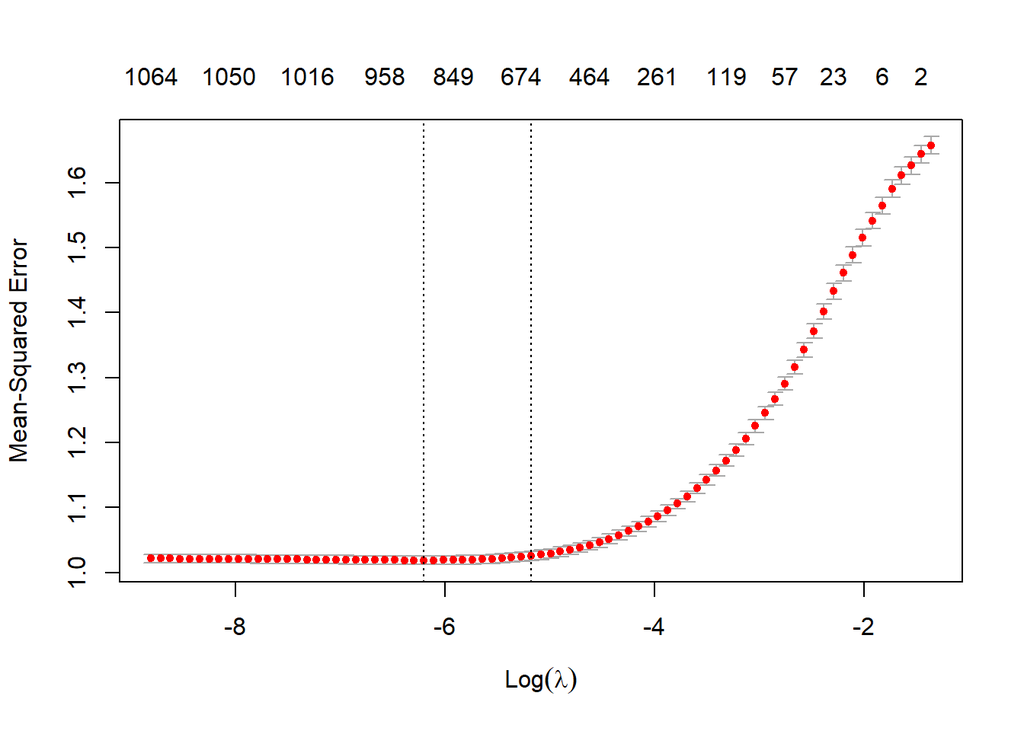

```r
# LASSO model using unigrams
data_dfm_train_amazon <- TAB_dfm(training_data_amazon$lemmatized_review_text, ngrams = 1)
data_dfm_test_amazon <- TAB_dfm(test_data_amazon$lemmatized_review_text, ngrams = 1, min.prop=0) %>%
  dfm_match(colnames(data_dfm_train_amazon))

data_model_amazon<-glmnet::cv.glmnet(x=data_dfm_train_amazon %>%
                               as.matrix(),y=training_data_amazon$rating)

plot_data_model <- plot(data_model_amazon)
```

```r
saveRDS(data_dfm_train_amazon, "function_data_dfm_train_amazon.rds")
saveRDS(data_dfm_test_amazon, "function_data_dfm_test_amazon.rds")
saveRDS(data_model_amazon, "function_data_model_amazon.rds")
```

Finally, we built a coefficients plot to visually interpret which words in the review text are the primary indicators of the rating (1 to 5 stars).

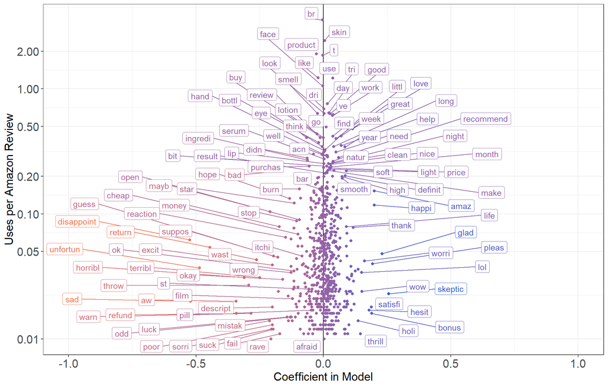

```r
# Coefficients plot
plotDat_amazon <- data_model_amazon %>%
  coef() %>%
  drop() %>%
  as.data.frame() %>%
  rownames_to_column(var = "ngram") %>%
  rename(score = ".") %>%
  filter(score != 0 & ngram != "(Intercept)" & !is.na(score))  %>%
  left_join(data.frame(ngram = colnames(data_dfm_train_amazon),
                       freq = colMeans(data_dfm_train_amazon)))

plotDat_amazon %>%
  mutate_at(vars(score, freq), ~round(., 3)) %>%
  ggplot(aes(x = score, y = freq, label = ngram, color = score)) +
  scale_color_gradient(low = "#F4744C", high = "#305DD0") +
  geom_vline(xintercept = 0) +
  geom_point() +
  geom_label_repel(max.overlaps = 45, force = 6) +
  scale_y_continuous(trans = "log2", breaks = c(-5, 0.01, 0.05, 0.1, 0.2, 0.5, 1, 2, 5)) +
  scale_x_continuous(limits = c(-1, 1)) +
  theme_bw() +
  labs(x = "Coefficient in Model", y = "Uses per Amazon Review") +
  theme(legend.position = "none",
        axis.title = element_text(size = 15),
        axis.text = element_text(size = 15))
```

The accuracy for our Lasso model is shown below.

```r
#Accuracies for the model
test_dfm_predict_amazon<-predict(data_model_amazon, newx = data_dfm_test_amazon)
model_amazon <- kendall_acc(test_dfm_predict_amazon,test_data_amazon$rating)

model_amazon
```

```
##              acc lower upper
## lambda.1se 73.07 72.41 73.73
```

**Transfer learning (use Amazon model to predict Sephora rating):**

In order to understand how well our model can be generalized to other skin care datasets, we applied some transfer learning and used our Lasso model to predict Sephora ratings.

```r
# Load Sephora reviews file
data_sephora<-read_csv("sephora_data.csv")
```

```
## ──────────────────────────────────────────────────────── Delimiter: "," chr
## (12): author_id, review_text, review_title, skin_tone, eye_color, skin_... dbl
## (9): ...1, Unnamed: 0, rating, is_recommended, helpfulness, total_feed... date
## (1): submission_time
```

```r
data_sephora <- data_sephora %>% rename(lemmatized_review_text = lemmatized_text)

data_dfm_test_sephora <- TAB_dfm(data_sephora$lemmatized_review_text, ngrams = 1, min.prop=0) %>%
  dfm_match(colnames(data_dfm_train_amazon))
```

The accuracy score shows that the model performs very well in other skin care reviews dataset.

```r
# Generate predictions for Sephora data
test_dfm_predict_sephora<-predict(data_model_amazon, data_dfm_test_sephora)

# Estimate accuracy
model_sephora<-kendall_acc(test_dfm_predict_sephora, data_sephora$rating)

model_sephora
```

```
##              acc lower upper
## lambda.1se 71.19 70.79 71.59
```

Finally, we built three benchmarks to understand how well we are performing in comparison to other models. The first benchmark is based on the word count per review, the second benchmark is based on random guess, finally the third benchmark is based on the average sentiment score for each review.The plot with all the accuracies is shown below.

```r
# Benchmarks
test_data_amazon <- test_data_amazon %>%
  mutate(text_wdct=word_count,
         model_random=sample(test_dfm_predict_amazon),
         sentiment=sentiment_by(lemmatized_review_text)$ave_sentiment)
# Benchmark 1 - Reviews word count
acc_wdct<-kendall_acc(test_data_amazon$rating,test_data_amazon$text_wdct)
acc_wdct
```

```
##     acc lower upper
## 1 51.62 50.87 52.36
```

```r
# Benchmark 2 - Random accuracy
acc_random<-kendall_acc(test_data_amazon$rating,test_data_amazon$model_random)
acc_random
```

```
##     acc lower upper
## 1 50.34  49.6 51.09
```

```r
# Benchmark 3 - Sentiment analysis
acc_sentiment<-kendall_acc(test_data_amazon$rating,test_data_amazon$sentiment)
acc_sentiment
```

```
##     acc lower upper
## 1 59.39 58.66 60.13
```

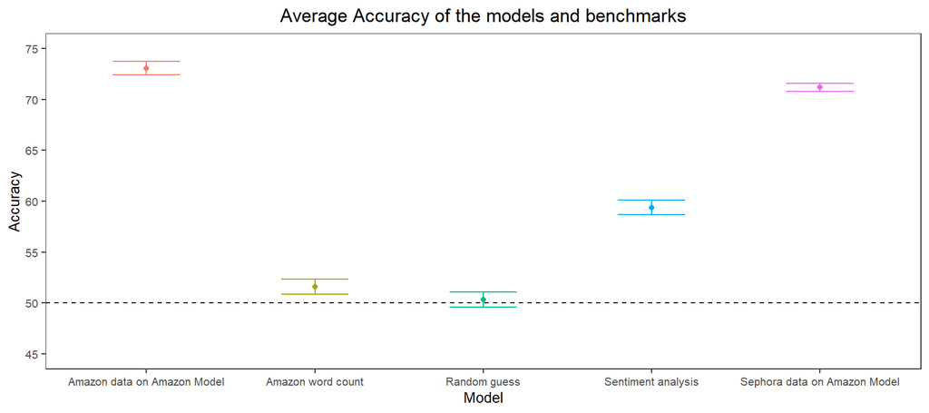

```r
# Combine accuracy estimates for a plot
accuracy_plot <- bind_rows(
  model_amazon %>% mutate(field = "Amazon data on Amazon Model"),
  model_sephora %>% mutate(field = "Sephora data on Amazon Model"),
  acc_wdct %>% mutate(field = "Amazon word count"),
  acc_random %>% mutate(field = "Random guess"),
  acc_sentiment %>% mutate(field = "Sentiment analysis")) %>%
  ggplot(aes(x=field,color=field,y=acc,ymin=lower,ymax=upper)) +
  geom_point() +
  geom_errorbar(width=.4) +
  theme_bw() +
  labs(x="Model",y="Accuracy") +
  geom_hline(yintercept = 50, linetype = "dashed") +
  ggtitle("Average Accuracy of the models and benchmarks") +
  theme(axis.text = element_text(size=8),
        axis.title = element_text(size=10),
        panel.grid=element_blank(),
        legend.position="none",
        plot.title = element_text(hjust = 0.5)) +
  scale_y_continuous(breaks = seq(45, 75, by = 5), limits = c(45, 75))

accuracy_plot
```